# Tutorial 7 - Correlação e Regressão

Victor Lobato dos Santos

# 1 Correlação

A correlação é o estudo da associação que existe entre variáveis(x e y). Podemos classificar a correlação como forte, fraca e nula, sendo ela linear ou não linear, positiva ou negativa.  
Os diagramas de dispersão, nos dão uma noção da correlação entre variáveis, porém, apenas o diagrama não pode ser considerado um indicador de correlação. Veja alguns exemplos de correlação, forte, fraca e nula através de gráficos de dispersão:

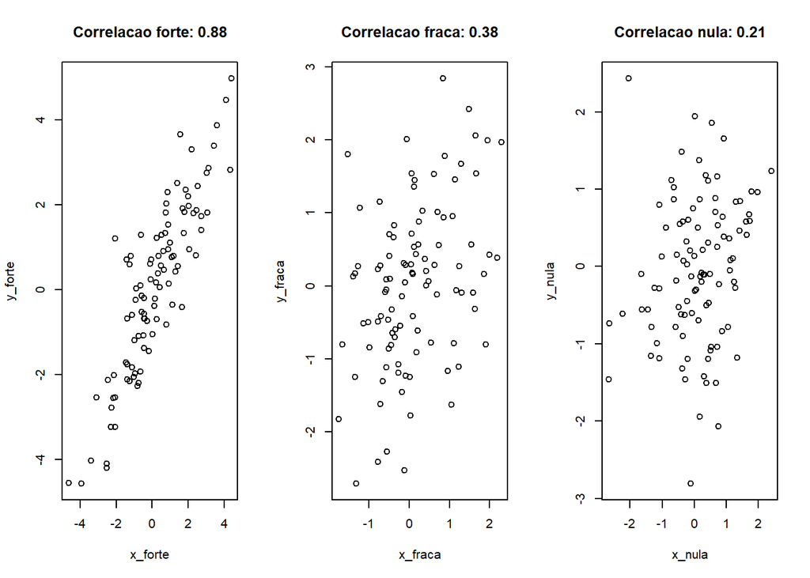

## 1.1 Correlação forte, fraca e nula

Na IDE do RStudio, podemos calcular uma correlação, utilizando a função `cor`, que calcula a correlação entre duas ou mais variáveis. É possível fazer este calculo tanto importando um conjunto de dados, como criando um conjunto de dados no R.  
Para exemplificar, iremos criar uma sequência de números pseudoaleatórios, através da função `set.seed`, que nos permite gerar números aleatórios de forma que seja possível replicalos e reproduzilos. Iremos também, utilizar a função `rnorm` para gerar números aleatórios a partir de uma distribuição normal e simular uma análise estatística.

A partir disso iremos calcular a correlação utilizando a função `cor` que por padrão, utiliza a fórmula do **coeficiente de correlação de Pearson** que nos dá uma medida de grau de correlação linear entre duas variáveis, sendo sua fórmula matemática dada por:

$$r = \frac{\sum xy - \frac{\left ( \sum x
\right )\left ( \sum y \right )}{n}}{\sqrt{\left [ \sum x^2 -
\frac{\left ( \sum x \right )^2}{n}\left [ \sum y^2\frac{\left ( \sum y
\right )^2}{n} \right ] \right ]}}$$

Vamos começar criando um exemplo para uma correlação forte:

```r
#criando uma reprodutibilidade de dados
set.seed(123)

#Criando as variáveis para os eixos x e y
x_forte <- rnorm(100, mean = 0, sd = 2)
y_forte <- x_forte + rnorm(100, mean = 0, sd = 1)
```

Em **y_forte** nós seguimos o mesmo padrão anterior, com diferença de que somamos a variável **x_forte** para criar uma relação e um padrão linear entre as variáveis.

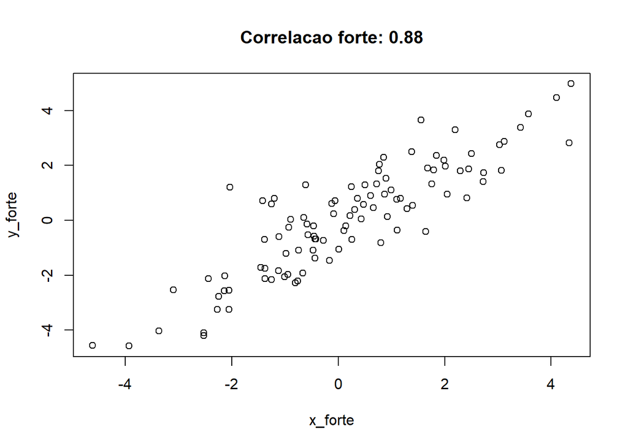

```r
#Calculando a correlação entre x_forte e y_forte
cor_forte <- cor(x_forte, y_forte)

#Criando o gráfico
plot(x_forte, y_forte, main = paste("Correlacao forte:", round(cor_forte, 2)))
```

Agora, seguindo os mesmos fundamentos, vamos criar um exemplo para **correlação fraca**:

```r
#Criando as variáveis
x_fraca <- rnorm(100, mean = 0, sd = 1)
y_fraca <- 0.5 * x_fraca + rnorm(100, mean = 0, sd = 1)
```

Seguindo o mesmo padrão, criamos duas variáveis, uma para o eixo x e outra para o eixo y. Na variável **x_fraca**, seguimos o mesmo passo anterior. Para a variável **y_fraca** nós seguimos também, o mesmo passo anterior, com a diferença de que aqui, nós multiplicamos 0.5 pela variável *x_fraca* para garantir a aleatoriedade entre as variáveis e definir o eixo y, igualando a metade dos valores do eixo x, de forma que ainda permaneça de forma linear e diretamente proporcional.

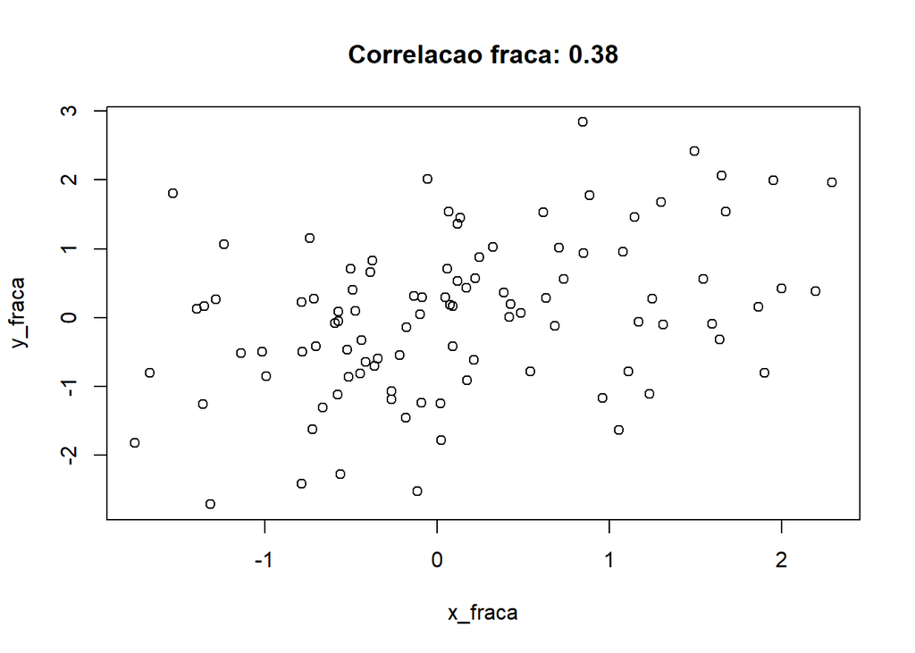

```r
#Calculando a correlação
cor_fraca <- cor(x_fraca, y_fraca)

#Criando o gráfico
plot(x_fraca, y_fraca, main = paste("Correlacao fraca:", round(cor_fraca, 2)))
```

A partir da mesma função `cor`, nós calculamos a correlação dos eixos x e y, referente a correlação fraca, e obtivemos um valor igual a aproximadamente 0.38, indicando uma correlação fraca. Em seguinda utilizamos a função `plot`, seguindo os mesmos passos anteriores. O resultado é um gráfico de dispersão que nos permite ter uma noção de uma correlação linear fraca entre variáveis.

Por último, vamos criar um exemplo de correlação nula, através dos padrões vistos anteriormente.

```r
#Criando as variáveis dos eixos x e y
x_nula <- rnorm(100, mean = 0, sd = 1)
y_nula <- rnorm(100, mean = 0, sd = 1)
```

Para criar as variáveis dos eixos x e y referente ao nosso exemplo de correlação nula, nós seguimos os mesmos passos anteriores, com a diferença que aqui, não somamos o eixo x ao eixo y, para que, de forma proposital, não exista uma relação linear entre as duas variáveis.

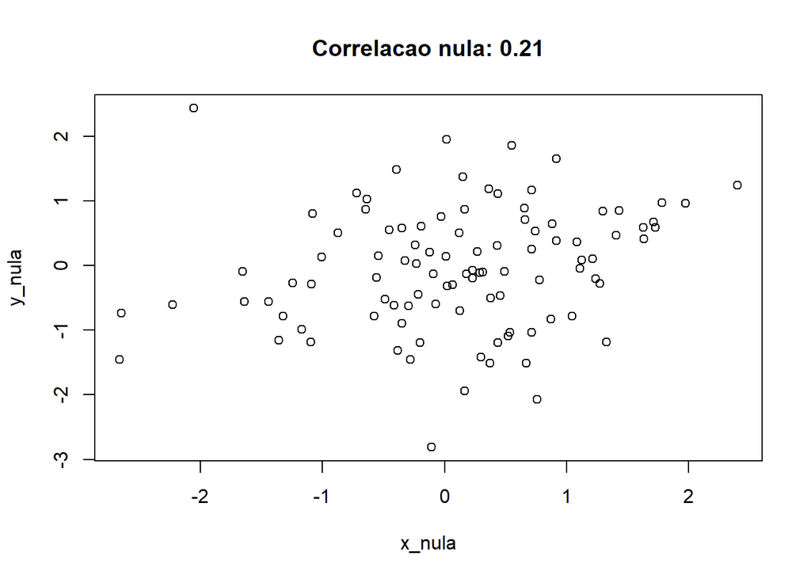

```r
#calculando a correlação
cor_nula <- cor(x_nula, y_nula)

#Criando o Gráfico
plot(x_nula, y_nula, main = paste("Correlacao nula:", round(cor_nula, 2)))
```

Através da função `cor` e seguindo o mesmo padrão dos exemplos anteriores, nós calculamos a correlação, e em seguida utilizamos a função `plot`, também seguindo os passos anteriores, para criar um gráfico de dispersão que nos permite ter uma noção de uma correlação nula entre duas variáveis.

## 1.2 Correlação linear e não linear

Sabe-se que a correlação é o estudo entre as variáveis e também, como elas estão relacionadas. Dessa forma, quando existe uma variação conjunta das variáveis, dizemos que existe uma correlação entre as variáveis. Ademais, temos tipos de correlações lineares e não lineares, que é possível identificar também através de um gráfico de dispersão. Vamos ver alguns exemplos de uma correlação linear e não linear abaixo:

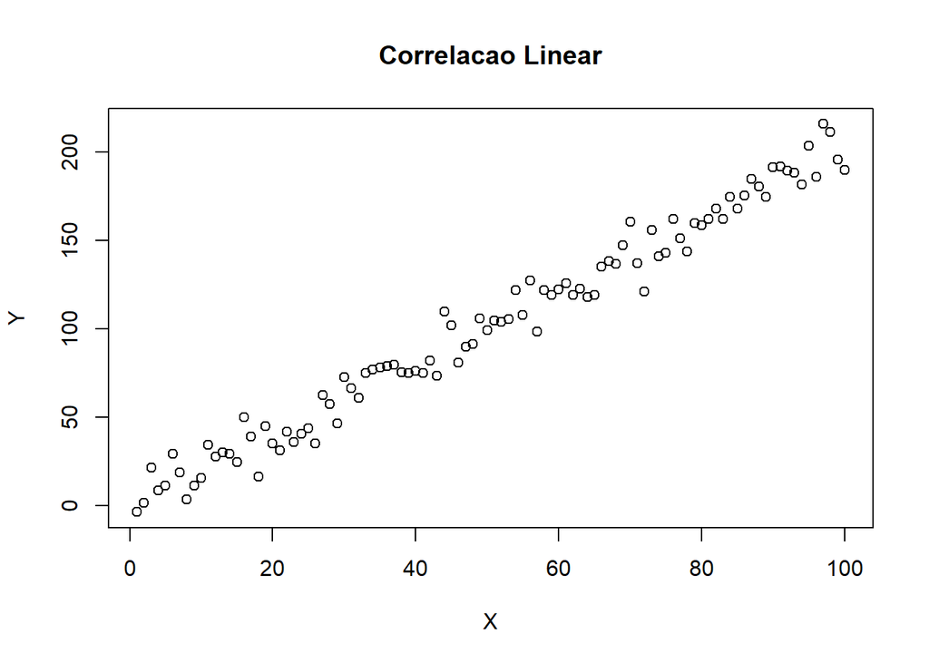

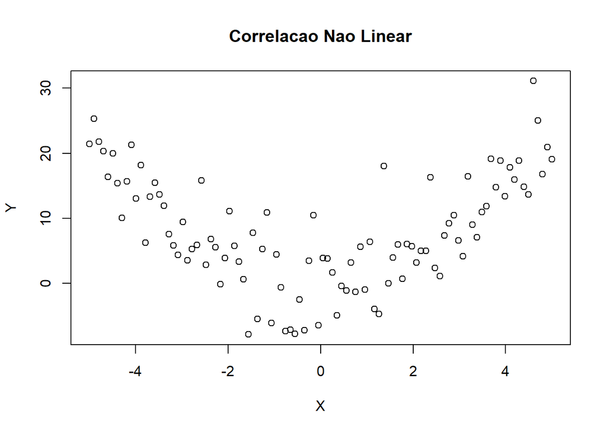

# 2 Regressão

A Regressão é a equação que representa a relação entre uma **variável resposta** (desfecho) e uma **variável explanatória** (fator).

Imagine por exemplo, que um medicamento aplicado em um paciente possui um tempo de aplicação (x) e uma melhoria da condição do paciente (y). O tempo de aplicação do medicamento é o **fator variável independente** enquanto que a melhoria da condição do paciente, é o **desfecho variável dependente**.

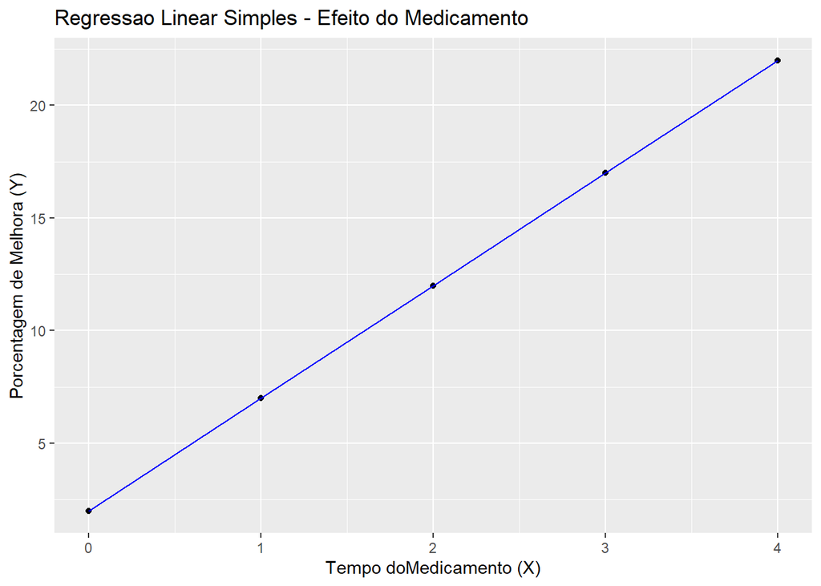

Neste exemplo, vemos uma regressão linear simples. Sua fórmula é dada por:

$$f(x) = bx + a$$

- $a = \bar{y} - b\bar{x}$ ;
- $b = \frac{\sum xy - \frac{\left ( \sum x \right )\left ( \sum y \right )}{n}}{\sum x^2 i \frac{\left ( \sum x \right )^2}{n}}$ ;
- **bx** é variável explanatória (preditiva).

## 2.1 Calculando Regressão linear simples no R

Com base nas fórmula, nós podemos calcular a regressão linear simples no na IDE do R, seguindo alguns passos:.

```r
# Criando os vetores
x <- c(0, 1, 2, 3, 4)
y <- c(2, 7, 12, 17, 22)


# Calculando o número de observações
n <- length(x)

# Calculando a soma de x, y, x*y, x^2 e y^2
sum_x <- sum(x)
sum_y <- sum(y)
sum_xy <- sum(x * y)
sum_x2 <- sum(x^2)

# Calculando o coeficiente b
b <- (sum_xy - (sum_x * sum_y) / n) / (sum_x2 - (sum_x^2) / n)

# Calculando o coeficiente a
a <- mean(y) - b * mean(x)

# Exibindo os coeficientes
cat("Coeficiente a (interceptação):", a, "\n")
```

```
## Coeficiente a (interceptação): 2
```

```r
cat("Coeficiente b (inclinação):", b, "\n")
```

```
## Coeficiente b (inclinação): 5
```

Vamos entender os passos realizados:

- Primeiro, nós criamos os vetores que contém os valores de x e y;
- Descobrimos nosso **n** referente a quantidade de dados contidas em x, utilizando a função `length`;
- Em seguida calculamos a soma de x, y, x*y, x² e y através da função `sum`;
- Para calcular o coeficiente b, referente a fórmula $b = \frac{\sum xy - \frac{\left ( \sum x \right )\left ( \sum y \right )}{n}}{\sum x^2 i \frac{\left ( \sum x \right )^2}{n}}$ da seguinte forma: criamos uma variável do somatório de xy (*sum_xy*), subtraimos pelo resultado da soma de x (*sum_x*) vezes a soma de y (*sum_y*) e dividimos pelo valor de n (*n*). Dividimos tudo isso pelo resultado da soma de x² (sum_x2) menos a soma de x ao quadrado (*sum_x^2*) dividida pelo valor de n;
- Para calcular o coeficente a referente a fórmula $a = \bar{y} - b\bar{x}$, criamos uma variável da média de y através da função (`mean`) menos o resultado da variável *b* multiplicado pela média de x (mean(x));
- Utilizamos a função cat, para nos mostrar uma visualização dos resultados.

Agora vamos criar um gráfico de regressão linear baseado em nossos resultados:

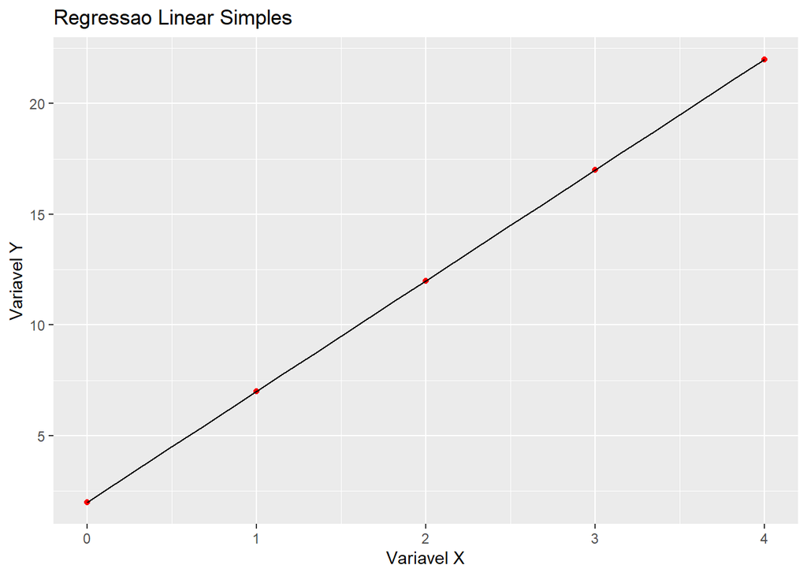

```r
# Calculando os valores previstos de y com base na equação

x_valor <- seq(min(x), max(x), length.out = 25)
y_valor <- a + b * x_valor


#Criando um dataframe para os pontos
dataframe_exemplo_reg <- data.frame(x = x_valor, y = y_valor)

#Criando o gráfico
grafico_reg <- ggplot() +
  geom_point(data = data.frame(x, y), aes(x, y), color = "red") +
  geom_line(data = dataframe_exemplo_reg, aes(x, y), color = "black" )+
  labs(x = "Variavel X", y = "Variavel Y", title = "Regressao Linear Simples")

grafico_reg
```

Vamos entender os passos da criação deste gráfico:

- Primeiro nós definimos o intervalo de valores de x para os quais nós queremos prever nos valores de Y. Para isso utilizamos o argumento `seq()` para criar um vetor com 25 valores, portanto, fizemos `seq(min(x), max(x), length.out = 25`. Com o argumento `seq` nós criamos um vetor com espaços iguais entre o valor mínimo e o valor máximo de x `seq(min(x), max(x))`, e com o argumento `length.out = 25` nós definimos a quantidade de valores desejados.
- Em seguida, criamos a variável `y_valor <- a + b * x_valor`, onde nós utilizamos a função de regressão linear simples $f(x) = a + bx$ para calcular os valores previstos de Y para cada um dos valores de X dentro do intervalo que nós definimos (25). Como já temos o resultado de a, b e x_valor, com base nas variáveis criadas, só precisamos aplicar a fórmula;
- O próximo passo foi criar um dataframe com nossos dados (`dataframe_exemplo_reg <- data.frame(x = x_valor, y = y_valor)`), aqui nós definimos a coluna x com a variável *x_valor* e a coluna y com a variável *y_valor*.

Utilizando a biblioteca **ggplot2** nós seguimos alguns passos para criar o gráfico:

- Primeiro nós **adicionamos os pontos no gráfico**, através da função `geom_point` onde especificamos quais dados queriamos usar através do argumento `data = data.frame(x, y)` definindo que queremos utilizar os dados contidos na variável x e y. Em seguida mapeamos as variáveis x e y através do argumento `aes(x, y)` e definimos a cor através do argumento `color`;
- **Adicionamos a linha de regressão** através da função `geom_line()`, onde especificamos que as linhas do noss gráfico serão referente aos dados contidos no nosso dataframe `data = data_exemplo_reg`, e da mesma forma anterior, mapeamos as variáveis x e y através do argumento `aes` e definimos a cor com o argumento `color`;
- **Adicionamos os rótulos e o título** do gráfico utilizando a função `labs()`, onde nós definimos os rotúlos pro eixo x e y e o título do gráfico através do argumento `title`

Lembrando que, interligamos todos os passos do gráfico, através do operador `+`. O resultado é um gráfico de regressão linear simples do nosso exemplo.

## 2.2 Calculando regressão com a função lm()

Um método comumente utilizado e relativamente mais simples de se calcular uma regressão no Rstudio, é utilizando a função `lm()`. Esta função pode ser usada para calcular e ajustar modelos de regressão linear. Abreviada da palavra “linear model” esta função é amplamente utilizada para modelar a relação de uma variável dependente (Y) e uma variável independente (X), com base na equação de linearidade.  
No tópico anterior, nós calculamos uma regressão linear, com base em uma equação específica, e por isso, desenvolvemos alguns passos para encontrar o resultado correto, mostrando que é possível desenvolver diferentes formas para se realizar análises no R.  
Vamos então, desenvolver um exemplo, com os mesmos valores de x e y vistos anteriormente, para calular e criar um gráfico de regressão linear utilizando a função `lm()`.

Imagine que você quer encontrar o templo de aplicação de um medicamento (x) em relação a porcentagem de melhora da condição de um paciente (Y):

```r
# data.frame exemplo
exemplo_reg <- data.frame(
  Medicamento = c(0, 1, 2, 3, 4),
  Melhora = c(2, 7, 12, 17, 22)
)

#Ajustando o modelo de regressão linear
modelo_reg <- lm(Melhora ~ Medicamento, data = exemplo_reg)

summary(modelo_reg)
```

```
##
## Call:
## lm(formula = Melhora ~ Medicamento, data = exemplo_reg)
##
## Residuals:
##          1          2          3          4          5
##  2.300e-15 -3.400e-15  9.515e-17  8.108e-16  1.943e-16
##
## Coefficients:
##              Estimate Std. Error   t value Pr(>|t|)
## (Intercept) 2.000e+00  1.874e-15 1.067e+15   <2e-16 ***
## Medicamento 5.000e+00  7.649e-16 6.537e+15   <2e-16 ***
## ---
## Signif. codes:  0 '***' 0.001 '**' 0.01 '*' 0.05 '.' 0.1 ' ' 1
##
## Residual standard error: 2.419e-15 on 3 degrees of freedom
## Multiple R-squared:      1,  Adjusted R-squared:      1
## F-statistic: 4.273e+31 on 1 and 3 DF,  p-value: < 2.2e-16
```

Vamos entender os passos para encontrar o resultado deste exemplo de regressão linear:

- Primeiro, nós criamos um data.frame com os valores referente ao eixo x (Medicamento) e eixo y (Melhora);
- Criamos a variável `modelo_reg` para armazenar os resultados da nossa regressão linear. Para `Melhora ~ Medicamento` nós especificamos que tipo de relação queremos modelar, nesse caso queremos modelar a variável independente (Medicamento) com a variável dependente (Melhora). Em seguida nós utilizamos o argumento `data = exemplo_reg` para especificar que queremos usar o dataframe *exemplo_reg* que contém os valores de x e y, em nossa regressão;
- Quando este código é executado, é feito um ajuste do modelo de regressão linear, de maneira automática. Ou seja, será calculado os coeficientes de inclinação e interceptação, que irão diminuir a soma dos quadrados dos erros existentes entre os valores contidos em “Melhora” para com os valores que serão previstos na linha de regressão;
- Com a função `summary()` nós exibimos um resumo completo do modelo, que nos mostra os coeficiente, os testes estatísticos, p-valores, coeficiente de determinação, dentre outros;

Agora, com base no modelo de regressão linear criado, vamos criar o gráfico:

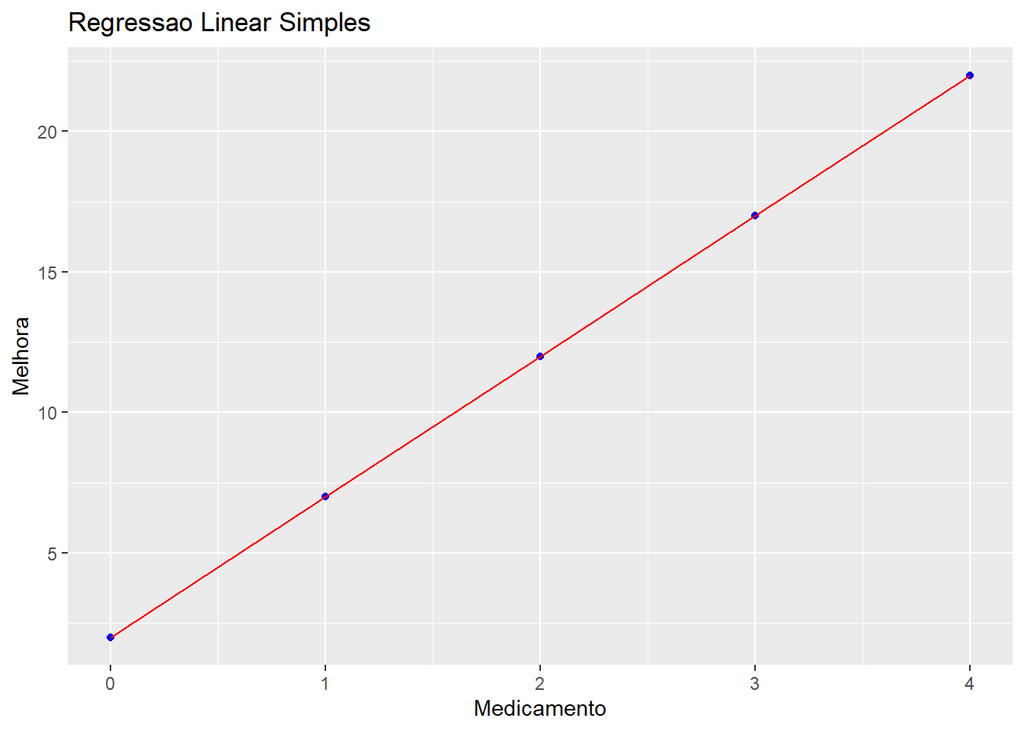

```r
#Criando o gráfico de regressão

grafico_reg_medicamento <- ggplot(data = exemplo_reg, aes(x = Medicamento, y = Melhora)) +
  geom_point(color = "blue") +
  geom_line(method = "lm", se = FALSE, color = "red") +
  labs(x = "Medicamento", y = "Melhora", title = "Regressao Linear Simples")

grafico_reg_medicamento
```

O resultado é um gráfico de regressão linear simples, utilizando a função `lm()` para encontrar a regressão.

# 3 Referências

- R Core Team (2022). R: A language and environment for statistical computing. R Foundation for Statistical Computing, Vienna, Austria. URL https://www.R-project.org/.
- H. Wickham. ggplot2: Elegant Graphics for Data Analysis. Springer-Verlag New York, 2016.